# Dinâmica de Perturbação na Ecologia da Paisagem

Implicações para Conservação e Ecologia Política

Felipe Melo - UFPE

## O Conceito de Distúrbio

- Evento discreto que causa modificação de um sistema
- Altera a disponibilidade de **recursos**
- Pode ser um evento natural ou de origem antrópica

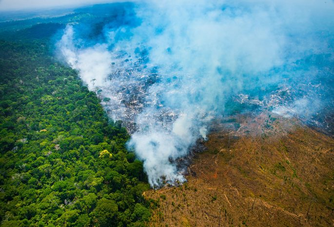

## O Paradigma Padrão-Processo

- O distúrbio é o motor que gera a heterogeneidade espacial
- Afeta a estrutura da paisagem spacio-temporalmente
- Padrões resultantes do distúrbio determinam as funções futuras do ecossistema

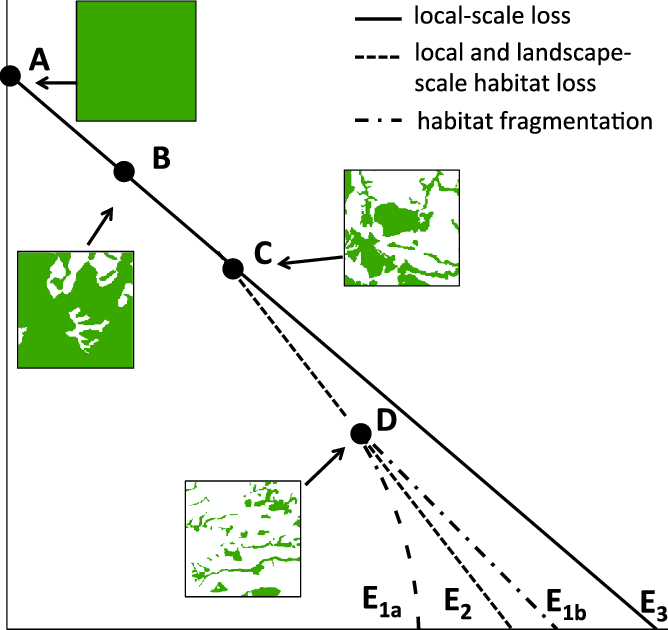

## Fontes “neutras” de perturbação

- Eventos geofísicos: fogo, tornados e deslizamentos
- Dinâmicas climáticas: enchentes, tempestades e geadas
- Ações bióticas: pragas e desequilíbrios populacionais

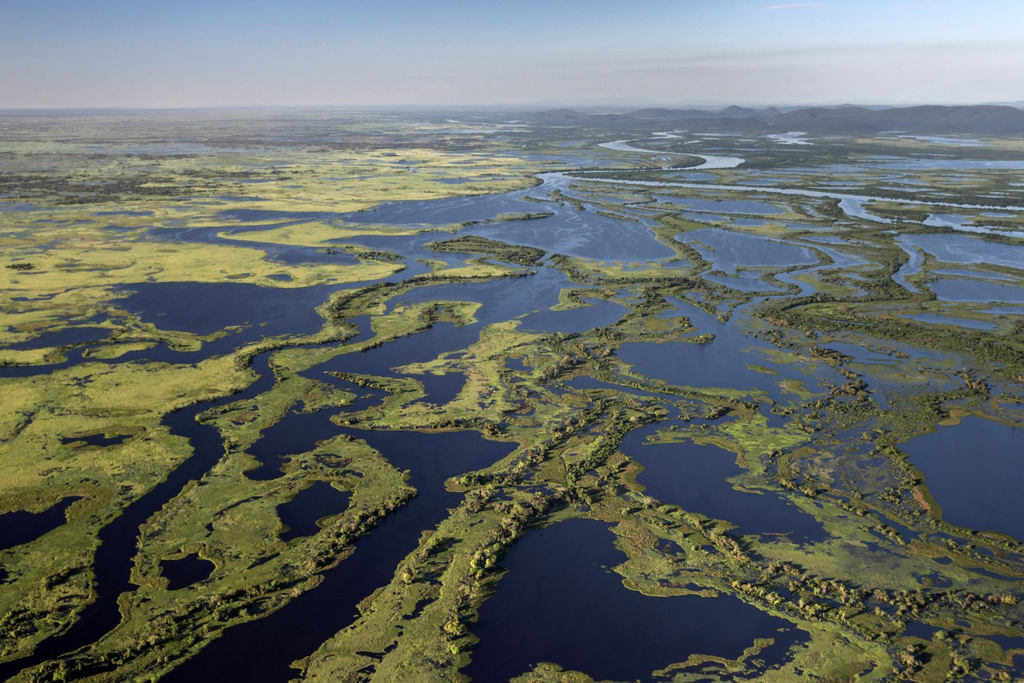

Pantanal Inundado

## Perturbações antrópicas contemporâneas

- Ação humana em escala sem precedentes históricos
- Mudança no uso do solo: agricultura e urbanização
- Infraestrutura linear: estradas e redes de transmissão

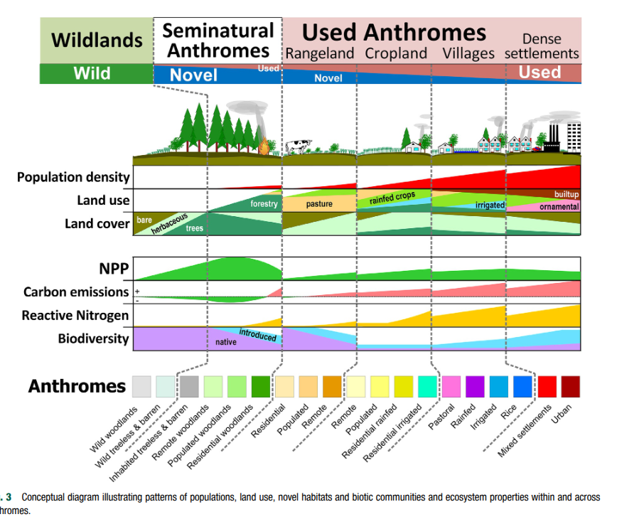

## Escalas temporais do distúrbio

- Padrões podem ser efêmeros ou permanecer por tempos geológicos
- A “memória” do distúrbio é frequentemente retida na paisagem

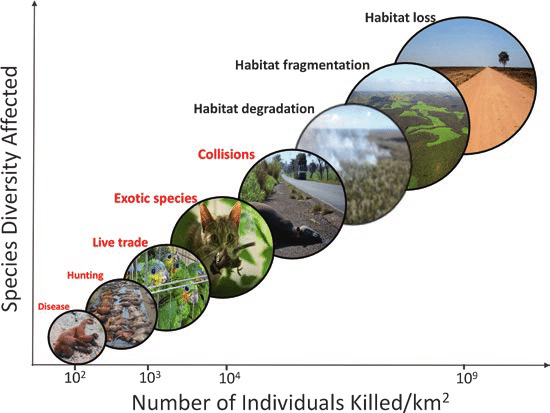

## Legados e rugosidades

- “Rugosidades”: formas antigas que restam de processos passados
- Paisagens atuais não são estáticas; carregam história embutida
- Mesmo áreas “intocadas” são fruto de decisões humanas históricas

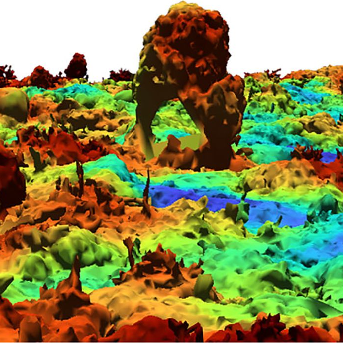

## Fragmentação como perturbação

- Divisão de habitats contínuos em manchas menores e isoladas
- Causa perda de conectividade funcional e aumento do isolamento
- Inserção de matrizes antrópicas no mosaico original

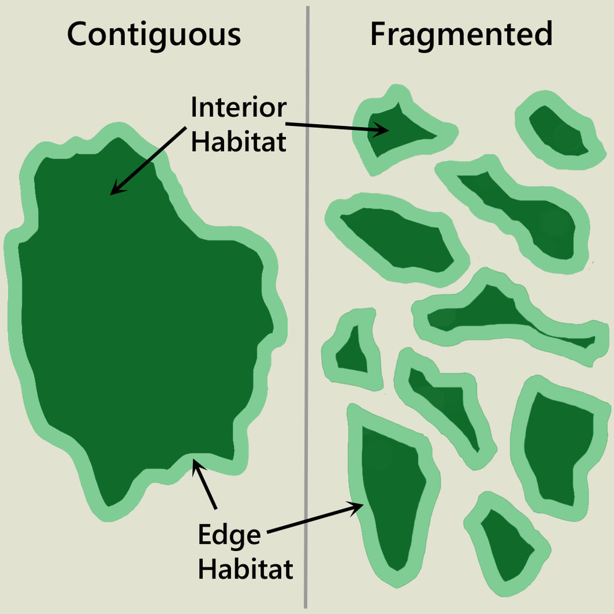

## O Efeito de Borda

- **Ecótono** entre manchas perturbadas e remanescentes naturais
- Alterações microclimáticas: maior entrada de luz e vento
- Impacta a estabilidade do interior dos fragmentos

[figure not shown]

## Distúrbios compostos e resiliência

- Interação entre múltiplos distúrbios (ex: seca seguida de fogo)
- Pode levar a sistemas a estados alternativos de degradação
- Desestabilização da capacidade de regeneração natural

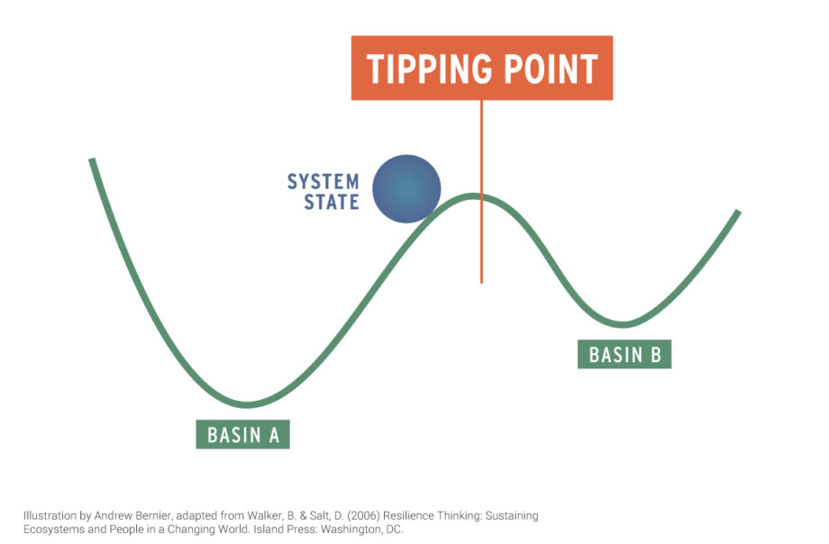

## Limiares críticos de extinção

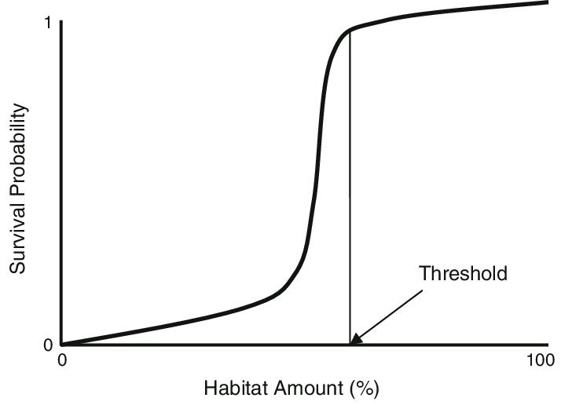

## Ecologia Política - Causas da perturbação

- Grandes empreendimentos: mineração, usinas e infraestrutura
- Expansão agrícola voltada para demandas globais
- Conflitos de poder e decisão sobre o uso do território

[figure not shown]

## Ecologia Política - Populações vulneráveis

- Comunidades locais que dependem de ecossistemas estáveis * Insegurança alimentar e escassez hídrica pós-distúrbio
- Populações excluídas dos benefícios da exploração de recursos

[figure not shown]

Os últimos Piripkura

## Ecologia de estradas e perturbação

- Estradas agem como vetores de espécies invasoras e doenças
- Causa fragmentação física e mortalidade por atropelamento
- Aumenta a capilaridade da interferência humana no território

[figure not shown]

## Percepção do distúrbio

- Diferentes organismos percebem a perturbação em escalas distintas
- Espécies especialistas são as mais impactadas pela mudança estrutural
- O que é matriz hostil para uma espécie pode ser habitat para outra

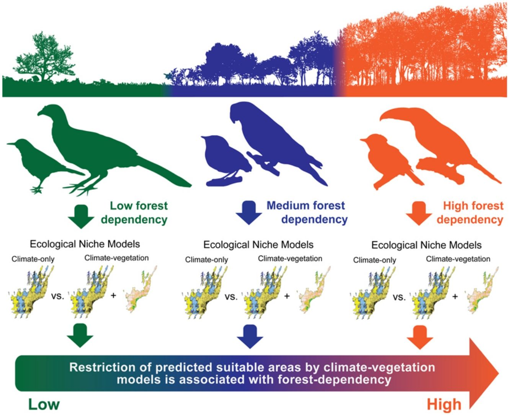

## Gestão Integrada de Paisagens (GIP)

- Conciliar objetivos sociais, econômicos e ambientais
- Conceito de Socio-ecossistemas
- Visão de longo prazo

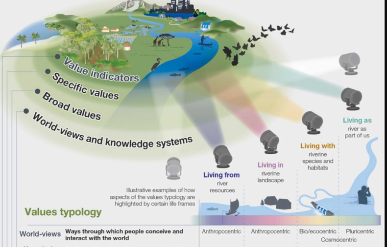

## Restauração no nível da paisagem

- Utiliza o regime de distúrbio como base para recuperação
- Abordagem de “4 Retornos”: natural, social, financeiro e inspiracional
- Restauração da conectividade funcional através de corredores

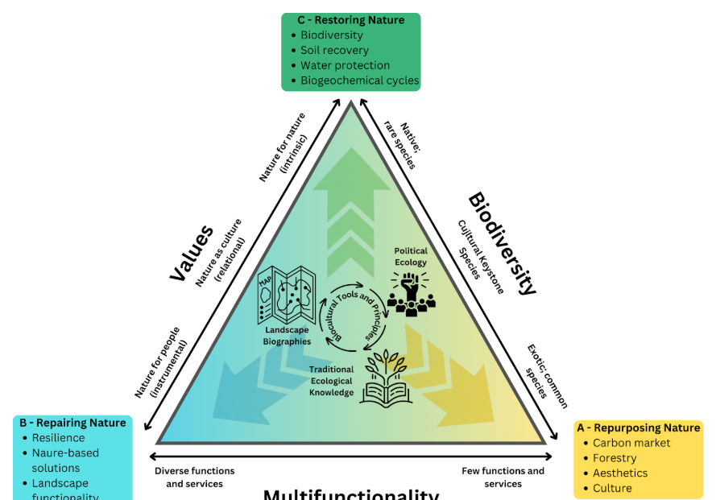

## Conservação e terras privadas

- A maior parte das terras e remanescentes está em mãos privadas no Brasil
- Impossível atingir metas (ex: 30x30) sem engajar proprietários rurais
- Necessidade de mecanismos legais e estímulos para conservação

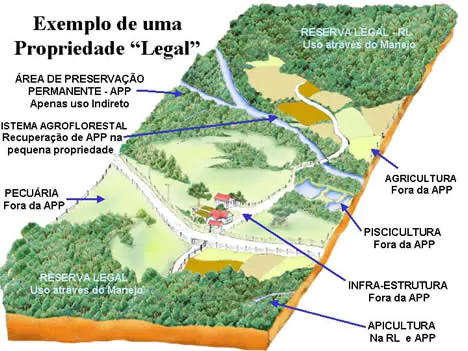

Propriedade “legal” segundo o código florestal

## Crise da biodiversidade e o antropoceno

- Interferência humana atingindo escala de força geológica
- Declínio drástico (70%) de populações de vertebrados desde 1970
- Ecologia de paisagem como resposta científica a essa crise

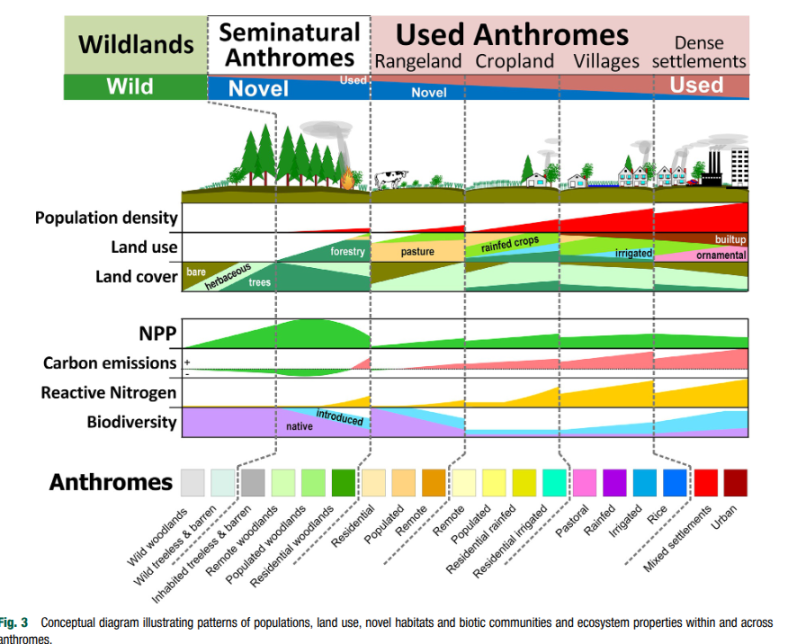

## Conclusão: planejar para a ação

- A escala da paisagem é a escala de ação do homem no seu meio
- Mudar o paradigma: o homem é parte integrante do sistema, não perturbador externo
- Planejar a paisagem como um todo para garantir sustentabilidade